# Create Daily Summaries

Curtis C. Bohlen, Casco Bay Estuary Partnership Revised 7/21/2020

- Load Libraries
- Load Sonde Data
  - Calculate daily summaries
  - Plot to confirm that did what we want….
- Load Weather Data
  - Address trace precipitation
- Combine data
  - Graphic to check….
- Export data
- Calculate Daily Exceedences
  - Thresholds
    - Dissolved oxygen
    - Chloride
    - Temperature
  - Calculate Exceedances
- Export data

# Load Libraries

```r
library(readr)
library(lubridate)
library(tidyverse)
```

# Load Sonde Data

```r
sonde_data <- read_csv("Sonde_Data.csv",
     col_types = cols(D = col_number(),
                      Press = col_number(),
                      pH = col_number()),
     progress=FALSE) %>%
  select(-X1)
```

```
## Warning: Missing column names filled in: 'X1' [1]
```

## Calculate daily summaries

This code generated an inordinate number of warnings, because minimums and maximums generate warnings whenever they are not well defined because of missing values. Here, we wrap relevant function calls in “suppressWarnings()” to minimize that effect.

The problem is not so much with generation of the warnings (which could be marginally useful), as the effect it has on slowing down execution of this code. Without suppressing these warnings, the code takes well over half an hour to run, With warnings suppressed, it only takes a minute or so.

Note that we downloaded the weather data in metric units, which is the default in our Python script for accessing NOAA weather data. Note that some data (like precipitation, snow depth, and temperature) are in tenths of units.

```r
daily_data <- sonde_data %>%
  mutate(sdate = as.Date(floor_date(DT, unit='day'))) %>%
  select(-DT, -Press, -Precip) %>%        # These items have a lot of missing values, slowing processing
  group_by(Site, sdate) %>%
  summarize_all(list(Min=~suppressWarnings(min(., na.rm=TRUE)),
                Max=~suppressWarnings(max(., na.rm=TRUE)),
                Mean=~mean(., na.rm=TRUE),
                Median=~median(., na.rm=TRUE),
                SD=~sd(., na.rm=TRUE),
                Iqr=~IQR(., na.rm=TRUE),
                n=~sum(! is.na(.)))) %>%
  mutate(Year = year(sdate)) %>%
  mutate(Month = month(sdate)) %>% ungroup()
```

## Plot to confirm that did what we want….

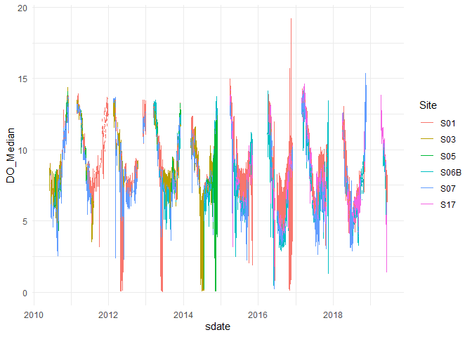

```r
plt <- daily_data %>% select(Site,sdate, DO_Median, Year) %>%
  ggplot(aes(sdate,DO_Median)) + geom_line(aes(color=Site, group=Year)) +
  theme_minimal()
plt
```

# Load Weather Data

The majority of the data bundled with the Portland Jetport weather data is not relevant to our needs.

```r
sibfldnm    <- 'Original_Data'
parent      <- dirname(getwd())
sibling     <- file.path(parent,sibfldnm)

fn <- "Portland_Jetport_2009-2019.csv"
fpath <- file.path(sibling, fn)

weather_data <- read_csv(fpath,
 col_types = cols(AWNDattr = col_skip(),
        FMTM = col_skip(), FMTMattr = col_skip(),
        PGTM = col_skip(), PGTMattr = col_skip(),
        PRCPattr = col_character(), SNOWattr = col_character(),
        SNWD = col_skip(), SNWDattr = col_skip(),
        TAVG = col_number(), TAVGattr = col_character(),
        TMIN = col_number(), TMINattr = col_character(),
        TMAX = col_number(), TMAXattr = col_character(),
        WDF2 = col_skip(), WDF2attr = col_skip(),
        WDF5 = col_skip(), WDF5attr = col_skip(),
        WESD = col_skip(), WESDattr = col_skip(),
        WSF2 = col_skip(), WSF2attr = col_skip(),
        WSF5 = col_skip(), WSF5attr = col_skip(),
        WT01 = col_skip(), WT01attr = col_skip(),
        WT02 = col_skip(), WT02attr = col_skip(),
        WT03 = col_skip(), WT03attr = col_skip(),
        WT04 = col_skip(), WT04attr = col_skip(),
        WT05 = col_skip(), WT05attr = col_skip(),
        WT06 = col_skip(), WT06attr = col_skip(),
        WT07 = col_skip(), WT07attr = col_skip(),
        WT08 = col_skip(), WT08attr = col_skip(),
        WT09 = col_skip(), WT09attr = col_skip(),
        WT11 = col_skip(), WT11attr = col_skip(),
        WT13 = col_skip(), WT13attr = col_skip(),
        WT14 = col_skip(), WT14attr = col_skip(),
        WT16 = col_skip(), WT16attr = col_skip(),
        WT17 = col_skip(), WT17attr = col_skip(),
        WT18 = col_skip(), WT18attr = col_skip(),
        WT19 = col_skip(), WT19attr = col_skip(),
        WT22 = col_skip(), WT22attr = col_skip(),
        station = col_skip())) %>%
  #select( ! starts_with('W')) %>%
  rename(sdate = date)
summary(weather_data)
```

```
##      sdate                 AWND             PRCP           PRCPattr
##  Min.   :2010-06-01   Min.   :  4.00   Min.   :   0.00   Length:3499
##  1st Qu.:2012-10-23   1st Qu.: 23.00   1st Qu.:   0.00   Class :character
##  Median :2015-03-17   Median : 31.00   Median :   0.00   Mode  :character
##  Mean   :2015-03-17   Mean   : 33.38   Mean   :  34.12
##  3rd Qu.:2017-08-08   3rd Qu.: 41.00   3rd Qu.:  15.00
##  Max.   :2019-12-31   Max.   :116.00   Max.   :1633.00
##
##       SNOW         SNOWattr              TMAX          TMAXattr
##  Min.   :  0.0   Length:3499        Min.   :-155.0   Length:3499
##  1st Qu.:  0.0   Class :character   1st Qu.:  56.0   Class :character
##  Median :  0.0   Mode  :character   Median : 144.0   Mode  :character
##  Mean   :  5.3                      Mean   : 140.2
##  3rd Qu.:  0.0                      3rd Qu.: 228.0
##  Max.   :564.0                      Max.   : 378.0
##
##       TMIN           TMINattr              TAVG           TAVGattr
##  Min.   :-271.00   Length:3499        Min.   :-193.00   Length:3499
##  1st Qu.: -32.00   Class :character   1st Qu.:  16.00   Class :character
##  Median :  44.00   Mode  :character   Median :  98.00   Mode  :character
##  Mean   :  39.31                      Mean   :  90.67
##  3rd Qu.: 122.00                      3rd Qu.: 179.00
##  Max.   : 244.00                      Max.   : 290.00
##                                       NA's   :1034
```

## Address trace precipitation

Trace rainfall is included in the database by including a measurement value of zero for precipitation, and including the value “T” as the first element in PRCPattr.

A total of 140 samples have the minimum value of measured rainfall of 0.3 mm. (Reading the metadata, that value corresponds to converting 1/100th of an inch to mm (0.254mm = 2.54(cm/inch)(10mm/cm) /100), and rounding). A higher frequency of observations, 385 of them, were recoded as having trace amounts of rainfall.

It is not obvious how to incorporate trace rainfall into analyses, or even whether it is important. Here we create a flag for trace rainfall and add it to weather_data. That way, later we can chose to incorporate it into analyses or not.

```r
weather_data <- weather_data %>%
  mutate(is_trace = substr(PRCPattr,1,1)=='T')
```

# Combine data

We combine data using “match” because we have data for multiple sites in daily_data, and therefore dates are not unique. Match correctly assigns weather data by date.

```r
yesterdayprecip <- c(NA, weather_data$PRCP[1 : length(weather_data$PRCP)-1])  # could have used dplyr::lag() here too.

daily_data <- daily_data %>%
  mutate(Precip  = weather_data$PRCP [match(daily_data$sdate, weather_data$sdate)],
         PPrecip = yesterdayprecip   [match(daily_data$sdate, weather_data$sdate)],
         MaxT    = weather_data$TMAX [match(daily_data$sdate, weather_data$sdate)])
rm(yesterdayprecip)
```

## Graphic to check….

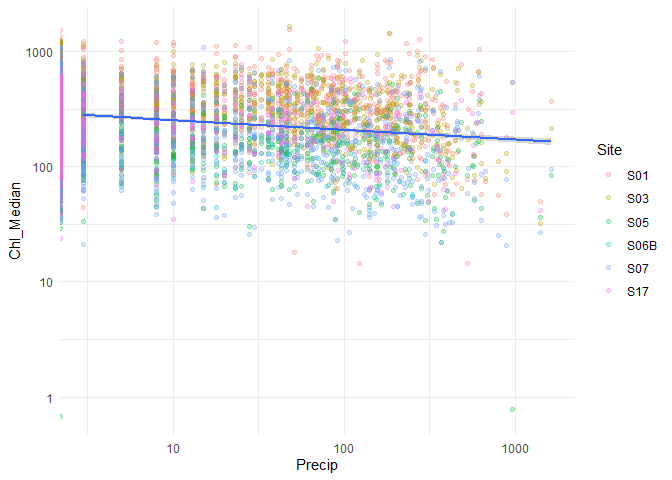

```r
plt <- ggplot(daily_data, aes(x=Precip, y=Chl_Median)) +
  geom_point(aes(color=Site), alpha=0.25) +
  scale_x_log10() +
  scale_y_log10() +
  geom_smooth(method='lm') +
  theme_minimal()

plt
```

# Export data

```r
write.csv(daily_data, 'Daily_Data.csv')
```

# Calculate Daily Exceedences

## Thresholds

Here we convert daily data to “dates during which”fail" or “Did not Fail” for each water quality standard or threshold

We have only a few criteria to look at:

### Dissolved oxygen

```r
tClassCDO <- 5      # Units are mg/l or PPM
tClassCPctSat <- 60
tClassBDO <- 7
tClassBPctSat <- 75
```

### Chloride

Maine uses established thresholds for both chronic and acute exposure to chloride. These are the “CCC and CMC” standards for chloride in freshwater. (06-096 CMR 584). These terms are defined in a footnote as follows:

> The Criteria Maximum Concentration (CMC) is an estimate of the highest concentration of a material in surface water to which an aquatic community can be exposed briefly without resulting in an unacceptable effect. The Criterion Continuous Concentration (CCC) is an estimate of the highest concentration of a material in surface water to which an aquatic community can be exposed indefinitely without resulting in an unacceptable effect.

The relevant thresholds are:

```r
tChlCCC <- 230  # units are mg/l or PPM
tChlCMC <- 860
```

### Temperature

There are no criteria for maximum stream temperature, but we can back into thresholds based on research on thermal tolerance of brook trout in streams. A study from Michigan and Wisconsin, showed that trout are found in streams with daily mean water temperatures as high as 25.3°C, but only if the period of exceedance of that daily average temperature is short – only one day. Similarly, the one day daily maximum temperature above which trout were not found was 27.6°C.

> Wehrly, Kevin E.; Wang, Lizhu; Mitro, Matthew (2007). “Field‐Based Estimates of Thermal Tolerance Limits for Trout: Incorporating Exposure Time and Temperature Fluctuation.” Transactions of the American Fisheries Society 136(2): 365-374.

```r
tMaxT <- 27.6   # Celsius
tAvgT <- 25.3
```

## Calculate Exceedances

```r
exceedance_data <- daily_data %>%
  select(sdate, Site, Year, Month, Precip, PPrecip, MaxT, DO_Min, PctSat_Min, Chl_Max, T_Max, T_Mean) %>%
  mutate(ClassCDO = DO_Min>=tClassCDO, ClassBDO = DO_Min>=tClassBDO,
         ClassC_PctSat = PctSat_Min>tClassCPctSat, ClassB_PctSat = PctSat_Min>tClassBPctSat,
         ClassCBoth = ClassCDO & ClassC_PctSat,
         ClassBBoth = ClassBDO & ClassB_PctSat,
         ChlCCC = Chl_Max<=tChlCCC, ChlCMC = Chl_Max <= tChlCMC,
         MaxT = T_Max <= tMaxT, AvgT = T_Mean <= tAvgT) %>%
  select(-DO_Min, -PctSat_Min, -Chl_Max, -T_Max, -T_Mean)
```

# Export data

```r
write.csv(exceedance_data, 'Exceeds_Data.csv')
```